# Coronavirus (COVID-19)

## Background

The spread of COVID-19 has severely taken affair in over **200 countries** worldwide. The outbreak was first detected in mainland China in December 2019. It was reported COVID-19 were originated from wet market in **Wuhan, China**. The virus could lead to an effect from mild to moderate upper-respiratory tract illnesses for instance **Severe Acute Respiratory Syndrome (SARS)**, **Middle East respiratory syndrome (MERS)** and **Common Cold**. According to World Health Organization (WHO) the transmissions are still under research.

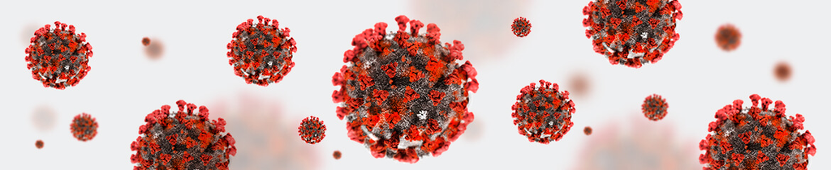

## Transmission of corona virus infection can be spread through;

- Airborne (aerosol), ex: dust or any kind of microbe
- Droplet spray and direct contact, ex: sneeze, hand shake
- Indirect (fomite), ex : Towel, doorknob, elevator button

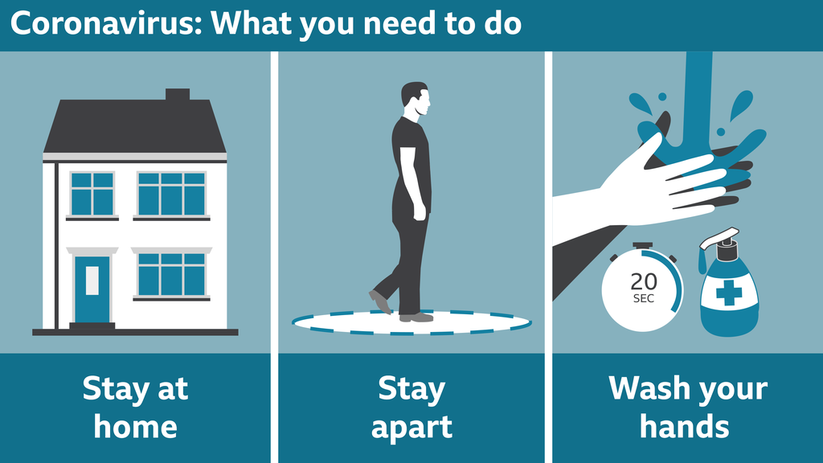

source: https://www.annualreviews.org/doi/pdf/10.1146/annurev-virology-012420-022445

## COVID-19 statistic situation by WHO as at 16th June 2020;

- 7,823,289 confirmed cases
- 431,541 deaths

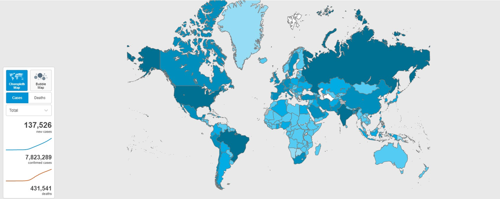

source: https://covid19.who.int/

## OBJECTIVE

COVID-19 Self Checker serve a purpose to diagnose and inform the user if they are exposed to COVID-19 based on input below

- Symptom (Cough, Fever, Sore Throat, Shortness of Breath, Headache)
- Age (either above 60 or below)
- Gender
- Travel history
- Close contact with positive patient

## Good News for the Travel Addict!!!

It is also a platform to **indentify affected country** area of COVID-19 in Worldwide. A music to ears for those **globetrotter** who like to travel. This could help them to prepare and take a **precaution** before visiting to the country upon COVID-19 pandemic.

[figure not shown]

## App Features

[figure not shown]

Main Interface

Options of cases and number of death are provided by allowing the user to tick in the box

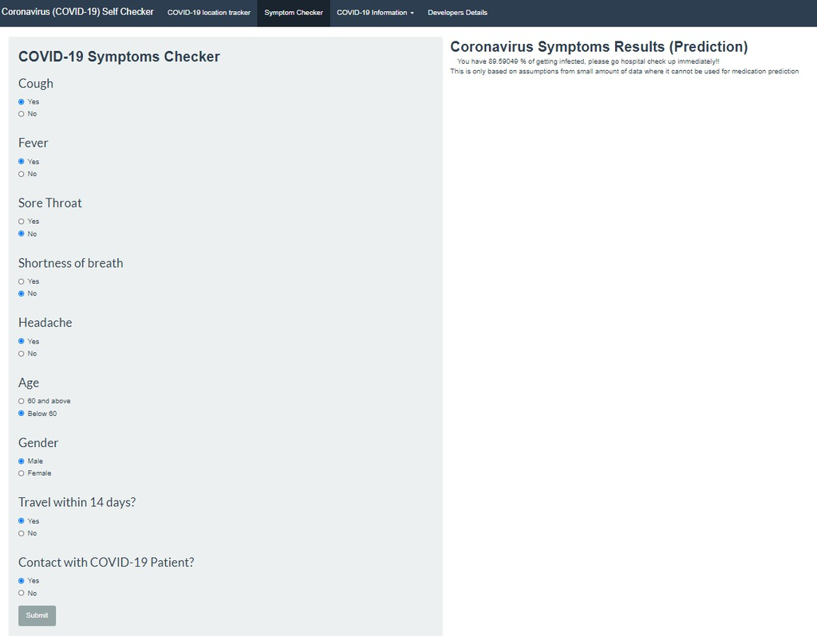

Symptom Checker Interface

## How does the app works?

To learn more about the app please click [here](https://kevinmunsiuhou.shinyapps.io/COVID-19_FINAL/). Our source [code](https://github.com/KevinMunSiuHou/COVID-19_Symptoms_Prediction_and_Map_Checker)